# Linear Regression

Kshitij Srivastava

11 April 2019

## Regression on Auto dataset

We will first fit a simple linear regression model using the **Auto** dataset. Next we will examine the fit using various diagnostic plots.

```r
library(ISLR)
head(Auto)
```

```
##   mpg cylinders displacement horsepower weight acceleration year origin
## 1  18         8          307        130   3504         12.0   70      1
## 2  15         8          350        165   3693         11.5   70      1
## 3  18         8          318        150   3436         11.0   70      1
## 4  16         8          304        150   3433         12.0   70      1
## 5  17         8          302        140   3449         10.5   70      1
## 6  15         8          429        198   4341         10.0   70      1
##                        name
## 1 chevrolet chevelle malibu
## 2         buick skylark 320
## 3        plymouth satellite
## 4             amc rebel sst
## 5               ford torino
## 6          ford galaxie 500
```

## Fitting a simple linear model

Let’s use mpg as response and horsepower as predictor

```r
modelFit <- lm(mpg~horsepower, data=Auto)
summary(modelFit)
```

```
##
## Call:
## lm(formula = mpg ~ horsepower, data = Auto)
##
## Residuals:
##      Min       1Q   Median       3Q      Max
## -13.5710  -3.2592  -0.3435   2.7630  16.9240
##
## Coefficients:
##              Estimate Std. Error t value Pr(>|t|)
## (Intercept) 39.935861   0.717499   55.66   <2e-16 ***
## horsepower  -0.157845   0.006446  -24.49   <2e-16 ***
## ---
## Signif. codes:  0 '***' 0.001 '**' 0.01 '*' 0.05 '.' 0.1 ' ' 1
##
## Residual standard error: 4.906 on 390 degrees of freedom
## Multiple R-squared:  0.6059, Adjusted R-squared:  0.6049
## F-statistic: 599.7 on 1 and 390 DF,  p-value: < 2.2e-16
```

We have got a good R squared value. R squared value is the amount of variance in the response, which can be explained by the predictor/s. We also see that the predictor has a low standard error and low p value which tells us that it’s statistically significant. The p value here tests the null hypothesis that keeping all other predictors constant (none right now), *horsepower* has no effect on *mpg*. We can reject the null hypothesis because of the low p-value. We also note that the relationship between mpg and horsepower is negative.

## Prediction using the model

Let’s try and predict the value of mpg when horsepower is 98. Also let’s get the confidence and prediction intervals around the prediction value. Prediction intervals are inherently wider than confidence intervals because they include the irreducible error in response as well.

```r
predict(modelFit, data.frame(horsepower = c(98)), type = "response")
```

```
##        1
## 24.46708
```

```r
predict(modelFit, data.frame(horsepower = c(98)), type = "response", interval = "confidence")
```

```
##        fit      lwr      upr
## 1 24.46708 23.97308 24.96108
```

```r
predict(modelFit, data.frame(horsepower = c(98)), type = "response", interval = "prediction")
```

```
##        fit     lwr      upr
## 1 24.46708 14.8094 34.12476
```

## Regression diagnostic

Let’s now plot the response and predictor

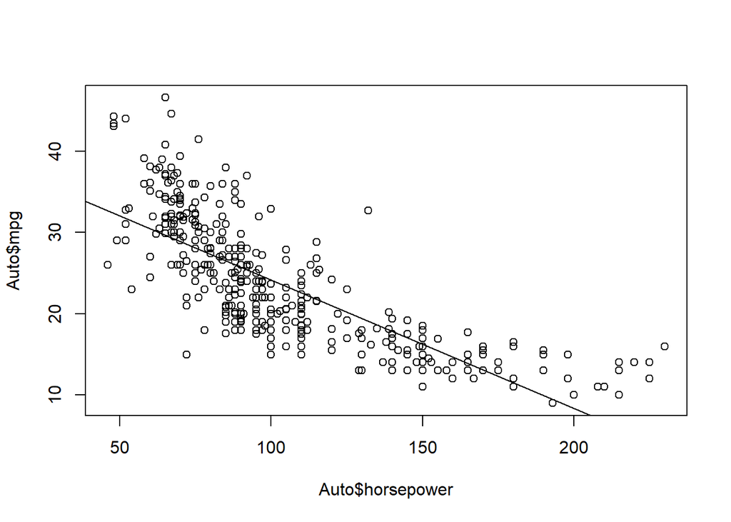

```r
plot(Auto$horsepower,Auto$mpg)
abline(modelFit)
```

We can see some hints of non-linearity here. Lets’s plot some diagnostics

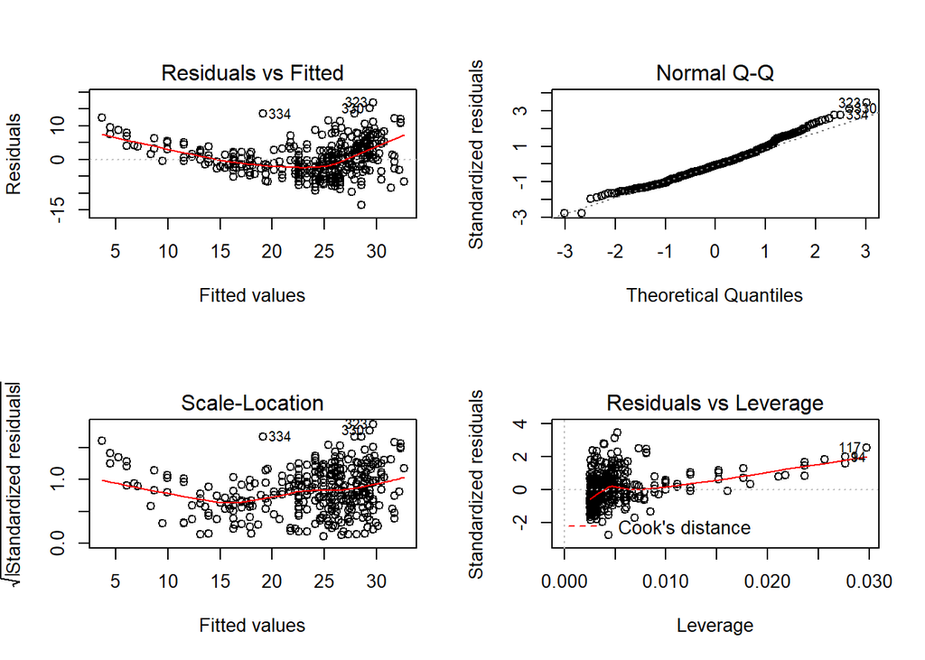

```r
par(mfrow=c(2,2))
plot(modelFit)
```

In the residuals vs fitted graph we can see a clear non-linear trend.